# Problem 1: Data Cleaning and Merging Incompatible Datasets

You are given two csv files (`Dataset_A` and `Dataset_B`) that contain genetic mutation information from a targeted mutation panel. However, the two datasets come from different sources, and column/row names differ. Your task is to merge the two datasets based on the appropriate columns. Assumptions may need to be made to merge the files. If you make an assumption to complete the task, mention it in the code and defend your assumption (ie, justify the assumption). After merging, identify and remove any duplicate entries. Identify any missing or anomalous data in the merged dataset. Describe your strategy for handling these missing values or anomalies. Deliverables: Submit the merged data, code used for merging the datasets and code for cleaning the data. Provide a brief explanation of the steps you took to handle column name incompatibility, missing values, and duplicates.

```python
import pandas as pd

# Load Dataset_A.csv into a DataFrame
df_A = pd.read_csv('Dataset_A.csv')

# Load Dataset_B.csv into a DataFrame
df_B = pd.read_csv('Dataset_B.csv')

# Display the first few rows of both DataFrames
df_A.head(), df_B.head()
```

```
(  SampleID Mutation   Gene  Location    Effect
 0       S1      T>A  BRCA1      3971    Silent
 1       S2      T>A   EGFR      4884    Silent
 2       S3      T>A   EGFR      7881  Nonsense
 3       S4      G>C  BRCA2      5156  Missense
 4       S5      T>A   EGFR      8238  Missense,
   PatientID Alteration  Chromosome    Impact
 0        P1        C>G           1  Moderate
 1        P2        A>T          14       Low
 2        P3        G>C          17       Low
 3        P4        A>T           5  Moderate
 4        P5        A>T          19      High)
```

It seems that `SampleID` from Dataset_A corresponds to `PatientID` in Dataset_B. I'll assume these columns represent the same entity (individual patients or samples), so I'll use these as the key for merging.

```python
# Renaming the columns to align similar data for merging
df_B_renamed = df_B.rename(columns={ "PatientID": "SampleID"})  # Assuming "PatientID" and "SampleID" are the same

# Replacing 'P' with 'S' in SampleID column of Dataset_B to match the format of SampleID in Dataset_A
df_B_renamed['SampleID'] = df_B_renamed['SampleID'].str.replace('P', 'S')

# Merging the datasets on the common column "SampleID"
merged_df = pd.merge(df_A, df_B_renamed, on="SampleID", how="outer")
```

```python
merged_df.head()
```

|  | SampleID | Mutation | Gene | Location | Effect | Alteration | Chromosome | Impact |
| --- | --- | --- | --- | --- | --- | --- | --- | --- |
| 0 | S1 | T>A | BRCA1 | 3971.0 | Silent | C>G | 1 | Moderate |
| 1 | S10 | A>T | BRCA2 | 8601.0 | Missense | G>C | 5 | Moderate |
| 2 | S100 | T>A | TP53 | 1287.0 | Silent | C>G | 11 | High |
| 3 | S1000 | C>G | BRCA2 | 3256.0 | Silent | G>C | 11 | Low |
| 4 | S1001 | A>T | TP53 | 1745.0 | Silent | C>G | 20 | Moderate |

```python
# Checking for duplicate rows and removing them
merged_df_no_duplicates = merged_df.drop_duplicates()

# Identifying missing data
missing_data = merged_df_no_duplicates.isnull().sum()

print(missing_data)
```

```
SampleID         0
Mutation      1000
Gene          1000
Location      1000
Effect        1000
Alteration       0
Chromosome       0
Impact           0
dtype: int64
```

### Check for NaN values:

```python
# Get all rows that contain NaN values
rows_with_nan = merged_df_no_duplicates[merged_df_no_duplicates.isnull().any(axis=1)]

# Print the rows with NaN values
print(rows_with_nan)
```

```
     SampleID Mutation Gene  Location Effect Alteration  Chromosome    Impact
4448    S5001      NaN  NaN       NaN    NaN        G>C          14      High
4449    S5002      NaN  NaN       NaN    NaN        T>A          12  Moderate
4450    S5003      NaN  NaN       NaN    NaN        G>C          20       Low
4451    S5004      NaN  NaN       NaN    NaN        T>A          19  Moderate
4452    S5005      NaN  NaN       NaN    NaN        G>C          18       Low
...       ...      ...  ...       ...    ...        ...         ...       ...
5551    S5996      NaN  NaN       NaN    NaN        G>C           5      High
5552    S5997      NaN  NaN       NaN    NaN        T>A          14  Moderate
5553    S5998      NaN  NaN       NaN    NaN        T>A          19  Moderate
5554    S5999      NaN  NaN       NaN    NaN        G>C          21       Low
5558    S6000      NaN  NaN       NaN    NaN        G>C           9      High

[1000 rows x 8 columns]
```

There are missing values `NaN` in the merged dataframe. The missing data (NaN values) in the merged dataset stems from the fact that Dataset_A has 5,000 samples and Dataset_B has 6,000 samples, but they don't have matching records for every sample. The missing values (`NaN`) in the dataset have been replaced with "Unknown". This way, it is clear when data is unavailable.

```python
merged_df_filled = merged_df_no_duplicates.fillna("Unknown")
```

### Check for anomalies:

```python
import numpy as np

# Dropping rows with 'Unknown' values
df_cleaned = merged_df_filled.replace("Unknown", pd.NA).dropna()

# Checking for anomalies in columns
categorical_columns = ['Mutation', 'Alteration', 'Gene', 'Impact' ,'Effect', 'Chromosome']

# Getting the unique values in each column to inspect for anomalies
anomalies_categorical = {col: np.array(sorted(df_cleaned[col].unique())) for col in categorical_columns}

# Checking the range of the 'Location' column for outliers (assuming valid locations are non-negative)
location_outliers = df_cleaned[df_cleaned['Location'] < 0]

# Displaying results: unique values in categorical columns and any outliers in 'Location'
anomalies_categorical, location_outliers
```

```
({'Mutation': array(['A>T', 'C>G', 'G>C', 'T>A'], dtype='<U3'),
  'Alteration': array(['A>T', 'C>G', 'G>C', 'T>A'], dtype='<U3'),
  'Gene': array(['BRCA1', 'BRCA2', 'EGFR', 'TP53'], dtype='<U5'),
  'Impact': array(['High', 'Low', 'Moderate'], dtype='<U8'),
  'Effect': array(['Frameshift', 'Missense', 'Nonsense', 'Silent'], dtype='<U10'),
  'Chromosome': array([ 1,  2,  3,  4,  5,  6,  7,  8,  9, 10, 11, 12, 13, 14, 15, 16, 17,
         18, 19, 20, 21, 22])},
 Empty DataFrame
 Columns: [SampleID, Mutation, Gene, Location, Effect, Alteration, Chromosome, Impact]
 Index: [])
```

1. `Location`: No negative or out-of-range values were found, meaning there are no apparent outliers
2. There are no obvious anomalies in the categorical or numeric columns. All values are within the expected ranges.

#### Final Merged Data:

```python
merged_data = merged_df_filled
merged_data
```

|  | SampleID | Mutation | Gene | Location | Effect | Alteration | Chromosome | Impact |
| --- | --- | --- | --- | --- | --- | --- | --- | --- |
| 0 | S1 | T>A | BRCA1 | 3971.0 | Silent | C>G | 1 | Moderate |
| 1 | S10 | A>T | BRCA2 | 8601.0 | Missense | G>C | 5 | Moderate |
| 2 | S100 | T>A | TP53 | 1287.0 | Silent | C>G | 11 | High |
| 3 | S1000 | C>G | BRCA2 | 3256.0 | Silent | G>C | 11 | Low |
| 4 | S1001 | A>T | TP53 | 1745.0 | Silent | C>G | 20 | Moderate |
| ... | ... | ... | ... | ... | ... | ... | ... | ... |
| 5995 | S995 | T>A | BRCA1 | 5981.0 | Silent | C>G | 15 | High |
| 5996 | S996 | T>A | BRCA1 | 3517.0 | Nonsense | T>A | 20 | Moderate |
| 5997 | S997 | G>C | BRCA1 | 9076.0 | Missense | C>G | 13 | High |
| 5998 | S998 | G>C | BRCA2 | 8291.0 | Nonsense | A>T | 7 | Low |
| 5999 | S999 | C>G | EGFR | 9040.0 | Missense | T>A | 21 | High |

6000 rows × 8 columns

#### Justifications for Assumptions:

`SampleID` in Dataset_A was assumed to correspond to `PatientID` in Dataset_B, since both likely represent individual samples or patients.

# Problem 2: Natural Language Processing for Biological Text

You are given a collection of research articles (in plain text format, see `article_1` through `article_5`) related to genetic mutations and their implications. Your task is to perform basic NLP tasks to analyze these articles. Calculate the frequency of the most common entities and plot the results in a bar chart. Deliverables: Submit the code used for the preprocessing. Submit a visualization showing the most frequent biological entities in the dataset. Provide a brief summary of your findings.

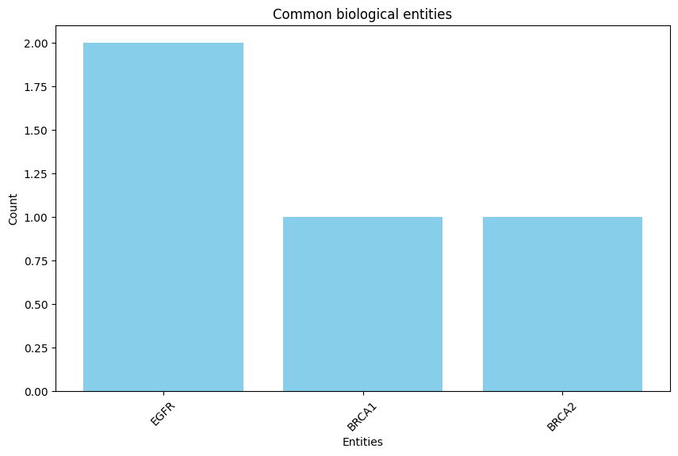

```python
import spacy
from pathlib import Path
from collections import Counter
import matplotlib.pyplot as plt

# Load spaCy model
nlp = spacy.load("en_core_web_sm")

file_paths = ['article_1.txt','article_2.txt','article_3.txt','article_4.txt','article_5.txt']

# Read and combine all the text from the files into one variable
text = "\n".join(Path(file).read_text() for file in file_paths)

# Process the text
doc = nlp(text)

# Extract entities and their labels
entities = [ent.text for ent in doc.ents]

# Count entity frequencies
entity_counts = Counter(entities)

# Get the most common entities
top_entities = entity_counts.most_common(10)

# Separate entities and counts for plotting
entity_labels = [entity[0] for entity in top_entities]
entity_frequencies = [count for entity, count in top_entities]

# Create the plot for entity labels and their frequencies
plt.figure(figsize=(10, 6))
plt.bar(entity_labels, entity_frequencies, color='skyblue')
plt.ylabel('Count')
plt.xlabel('Entities')
plt.title('Common biological entities')
plt.xticks(rotation=45)
plt.show()
```

- `EGFR`: Appears 2 times, indicating its strong relevance in the context of lung cancer.
- `BRCA1`: Appears 1 time, highlighting its critical role in breast and ovarian cancer.
- `BRCA2`: Appears 1 time, linking it to prostate and pancreatic cancers.
- These genes are all highly relevant in cancer research, and their mutations are crucial for understanding cancer risks and developing targeted treatments.

# Problem 3: Mutation Prediction Using Machine Learning

You are provided with a dataset (`ML_dataset.csv`) of genetic mutations and their clinical outcomes. The dataset contains the following columns:

Your task is to build a machine learning model to predict the clinical outcome based on the available features. Evaluate your model’s performance on the test set using appropriate metrics (e.g., accuracy, precision, recall, F1-score). Provide a brief explanation of the model selection process and your rationale behind it. Deliverables: Submit the code used for training and evaluating the model. Submit the performance metrics of the model along with a short interpretation. Provide a ROC curve if applicable.

```python
import pandas as pd
from sklearn.model_selection import train_test_split
from sklearn.preprocessing import LabelEncoder
import lightgbm as lgb
from lightgbm import early_stopping
import matplotlib.pyplot as plt
from sklearn.metrics import roc_curve
from sklearn.metrics import accuracy_score, precision_score, roc_auc_score, recall_score, f1_score, classification_report


# Load the CSV file into a DataFrame
df = pd.read_csv('ML_dataset.csv')

# Encode the categorical features in a separate variable
encoded_features = df[['Gene', 'Mutation', 'Effect']].copy()

# Apply label encoding to each categorical feature
for col in encoded_features.columns:
    le = LabelEncoder()
    encoded_features[col] = le.fit_transform(df[col])

# Combine the encoded features with the rest of the data (e.g., 'Location')
X = pd.concat([encoded_features, df[['Location']]], axis=1)
y = df['ClinicalOutcome']

# Split the data into training and testing sets
X_train, X_test, y_train, y_test = train_test_split(X, y, test_size=0.2, random_state=42)

# Initialize LightGBM model
lgb_train = lgb.Dataset(X_train, y_train)
lgb_test = lgb.Dataset(X_test, y_test, reference=lgb_train)

# Set parameters for LightGBM
params = {
    'objective': 'binary',
    'metric': 'auc',
    'boosting_type': 'gbdt',
    'num_leaves': 31,
    'learning_rate': 0.05,
    'verbosity': -1
}

# Train the model
lgb_model = lgb.train(params, lgb_train, valid_sets=lgb_test, num_boost_round=100, callbacks=[early_stopping(stopping_rounds=10)])

# Make predictions
y_pred_proba = lgb_model.predict(X_test, num_iteration=lgb_model.best_iteration)
y_pred = (y_pred_proba > 0.5).astype(int)  # converting probabilities to binary predictions

# Calculate AUC score
auc_score = roc_auc_score(y_test, y_pred_proba)

# Calculate other metrics
accuracy = accuracy_score(y_test, y_pred)
precision = precision_score(y_test, y_pred)
recall = recall_score(y_test, y_pred)
f1 = f1_score(y_test, y_pred)

# Generate classification report
classification_rep = classification_report(y_test, y_pred)

# Display the metrics
print("\n")
print(f"Accuracy: {accuracy}")
print(f"Precision: {precision}")
print(f"Recall: {recall}")
print(f"F1-score: {f1}")
print(f"AUC score: {auc_score}")
print("\n")
print("Classification Report:\n", classification_rep)

# Plot feature importance
# lgb.plot_importance(lgb_model, max_num_features=10)
# plt.show()
```

```
Training until validation scores don't improve for 10 rounds
Early stopping, best iteration is:
[3]	valid_0's auc: 0.519207


Accuracy: 0.535
Precision: 0.5187165775401069
Recall: 0.5987654320987654
F1-score: 0.5558739255014327
AUC score: 0.5192010536260429


Classification Report:
               precision    recall  f1-score   support

           0       0.56      0.47      0.51       514
           1       0.52      0.60      0.56       486

    accuracy                           0.54      1000
   macro avg       0.54      0.54      0.53      1000
weighted avg       0.54      0.54      0.53      1000
```

### Summary of the Classification Report:

- **Accuracy**: 54% – The model correctly predicts the class for 54% of the instances, slightly better than random guessing.
- **Class 0** (Negative Class):
  - **Precision**: 56% – Out of all predicted negatives, 56% are correct.
  - **Recall**: 47% – The model correctly identifies 47% of all actual negatives.
  - **F1-score**: 0.51 – The balance between precision and recall for class 0.
- **Class 1** (Positive Class):
  - **Precision**: 52% – Out of all predicted positives, 52% are correct.
  - **Recall**: 60% – The model correctly identifies 60% of all actual positives.
  - **F1-score**: 0.56 – The balance between precision and recall for class 1.

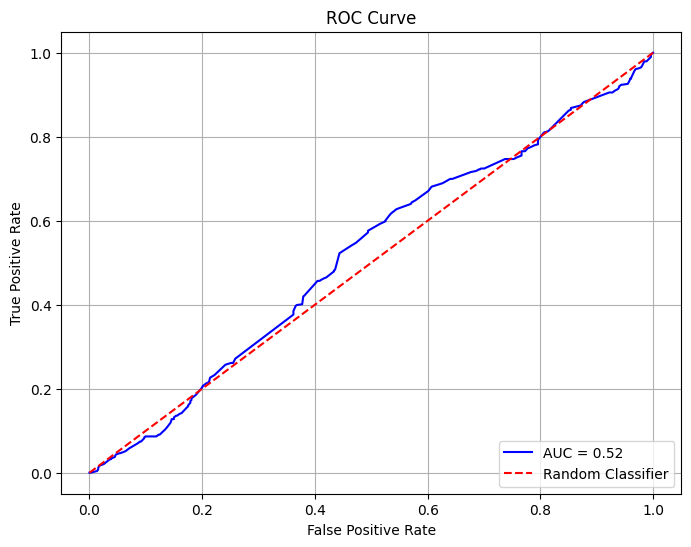

```python
# Calculate the ROC curve values
fpr, tpr, thresholds = roc_curve(y_test, y_pred_proba)

# Plot the AUC curve
plt.figure(figsize=(8, 6))
plt.plot(fpr, tpr, color='blue', label=f'AUC = {auc_score:.2f}')
plt.plot([0, 1], [0, 1], color='red', linestyle='--', label='Random Classifier')
plt.title('ROC Curve')
plt.xlabel('False Positive Rate')
plt.ylabel('True Positive Rate')
plt.legend(loc='lower right')
plt.grid(True)
plt.show()
```

The LightGBM model achieved **54% accuracy**, with an **AUC score of 0.52**, indicating that its predictions are only marginally better than random chance. This suggests that the features used in the dataset do not provide strong predictive power for the clinical outcome.

### Model Selection Rationale:

LightGBM was chosen for its efficiency with categorical data, scalability, and boosting capabilities. However, the performance suggests that further improvement is needed, including **feature engineering**, and **hyperparameter tuning**.

# Problem 4: Visualizing Mutation Data

You are given a dataset containing information about the frequency of specific genetic mutations observed in a targeted panel test (mutation_data). The dataset has columns like `Gene`, `Mutation`, `MutationType`, and `Frequency`.

```python
import pandas as pd
import matplotlib.pyplot as plt
import seaborn as sns

# Load the CSV file into a pandas dataframe
file_path = '/Users/sq566/Desktop/sophia/mutation_data.csv'
mutation_data = pd.read_csv(file_path)

# Group the data by 'Gene' and 'MutationType', then calculate the mean frequency for each group
mean_frequency_combinations = mutation_data.groupby(['Gene', 'MutationType'])['Frequency'].mean().reset_index()

# Display the result
display(mean_frequency_combinations)
```

|  | Gene | MutationType | Frequency |
| --- | --- | --- | --- |
| 0 | BRCA1 | Deletion | 51.484486 |
| 1 | BRCA1 | Insertion | 45.720245 |
| 2 | BRCA1 | Substitution | 53.511586 |
| 3 | BRCA2 | Deletion | 54.324245 |
| 4 | BRCA2 | Insertion | 49.848145 |
| 5 | BRCA2 | Substitution | 50.956619 |
| 6 | EGFR | Deletion | 54.769641 |
| 7 | EGFR | Insertion | 48.256530 |
| 8 | EGFR | Substitution | 47.731910 |
| 9 | TP53 | Deletion | 52.608274 |
| 10 | TP53 | Insertion | 48.770569 |
| 11 | TP53 | Substitution | 49.520272 |

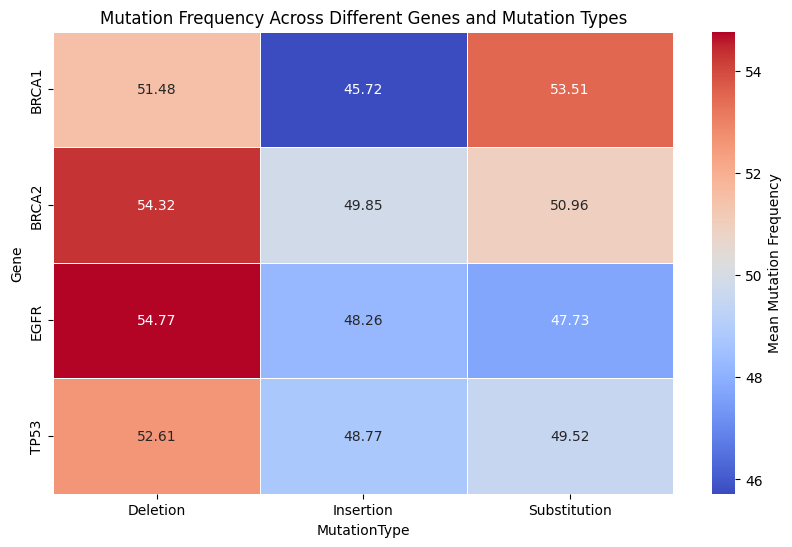

```python
heatmap_data = mutation_data.pivot_table(index='Gene', columns='MutationType', values='Frequency', aggfunc='mean')

# Create a heatmap to visualize mutation frequency across different genes
plt.figure(figsize=(10, 6))
sns.heatmap(heatmap_data, cmap='coolwarm', annot=True, cbar_kws={'label': 'Mean Mutation Frequency'}, fmt=".2f", linewidths=.5)
plt.title('Mutation Frequency Across Different Genes and Mutation Types')
plt.show()
```

The heatmap shows the mean mutation frequency across different genes (BRCA1, BRCA2, EGFR, and TP53) and mutation types (Deletion, Insertion, and Substitution). The colors indicate mean mutation frequency, with red hues representing higher frequencies and blue hues indicating lower frequencies.

### Heatmap Insights:

- **Deletions** show the highest frequencies in BRCA2 and EGFR and are also high in TP53, indicating a prevalent and potentially impactful mutation type for these genes.
- **Insertions** are observed with lower frequencies across all genes, especially in BRCA1, suggesting that while they are frequent in count, their impact or occurrence per gene is relatively lower.
- **Substitutions** are most prominent in BRCA1, indicating a significant role for this mutation type. Their frequencies in BRCA2 and TP53 are also noteworthy, though less than those in BRCA1.

### Scatter Plot

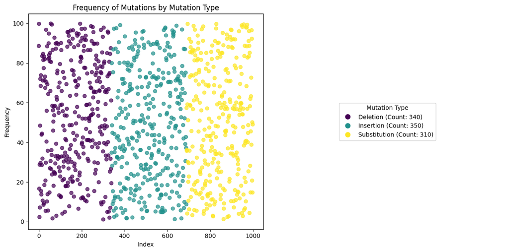

```python
import matplotlib.pyplot as plt
import pandas as pd
import numpy as np

# Create a color map for mutation types
mutation_data = mutation_data.sort_values(by='MutationType', ascending=True)
mutation_types = mutation_data['MutationType'].unique()
colors = plt.cm.viridis(np.linspace(0, 1, len(mutation_types)))
type_color_map = dict(zip(mutation_types, colors))

# Assign colors based on mutation type
mutation_data['Color'] = mutation_data['MutationType'].map(type_color_map)

# Count the occurrences of each mutation type
mutation_counts = mutation_data['MutationType'].value_counts()

# Create a figure and two subplots
fig, axs = plt.subplots(1, 2, figsize=(12, 6))

# Plotting frequency values colored by mutation type
axs[0].scatter(range(len(mutation_data)), mutation_data['Frequency'],
                c=mutation_data['Color'], alpha=0.7)
axs[0].set_title('Frequency of Mutations by Mutation Type')
axs[0].set_ylabel('Frequency')
axs[0].set_xlabel('Index')

# Create a separate legend
handles = [plt.Line2D([0], [0], marker='o', color='w',
                       markerfacecolor=type_color_map[mtype], markersize=10,
                       label=f'{mtype} (Count: {mutation_counts[mtype]})')
           for mtype in mutation_types]
axs[1].legend(handles=handles, title='Mutation Type', loc='center')
axs[1].axis('off')  # Hide axes for the legend subplot

# Show plot
plt.tight_layout()
plt.show()
```

From the visualization, it is clear that Insertion mutations are the most common type of mutation, followed by Deletion and then Substitution

# Problem 5: Aligning Multiple Panels

You are provided with data from two different mutation panels. One is a commercial panel, and the other is an in-house panel. Both panels list genes and mutation types, but the commercial panel includes additional annotations. Your task is to align the data from the two panels and identify which genes and mutations are shared between them and which are unique to each panel. Highlight any discrepancies in mutation annotations and suggest how to resolve these. Present the aligned data in a clean, understandable format.

```python
import pandas as pd
from IPython.display import display_html

# Load the provided CSV files
commercial_panel_path = 'commercial_panel.csv'
in_house_panel_path = 'in_house_panel.csv'

# Read the data into DataFrames
commercial_panel_df = pd.read_csv(commercial_panel_path)
in_house_panel_df = pd.read_csv(in_house_panel_path)

# Display the first few rows and the column names of each DataFrame for inspection
commercial_panel_df_info = commercial_panel_df.head(), commercial_panel_df.columns
in_house_panel_df_info = in_house_panel_df.head(), in_house_panel_df.columns

print(commercial_panel_df_info), print(in_house_panel_df_info)
```

```
(    Gene MutationType     Annotation
0   PTEN     Missense  Moderate Risk
1   PTEN   Frameshift       Low Risk
2  BRCA1     Missense      High Risk
3   KRAS       Silent  Moderate Risk
4   PTEN   Frameshift  Moderate Risk, Index(['Gene', 'MutationType', 'Annotation'], dtype='object'))
(    Gene MutationType
0  BRCA2       Silent
1   BRAF     Missense
2  BRCA1       Silent
3   EGFR     Nonsense
4  BRCA2    Insertion, Index(['Gene', 'MutationType'], dtype='object'))
```

```
(None, None)
```

#### Next Steps:

```python
# Merge the two panels on 'Gene' and 'MutationType' to find shared mutations
merged_df = pd.merge(commercial_panel_df, in_house_panel_df, on=['Gene', 'MutationType'], how='outer', indicator=True)

# Split the merged data into shared mutations, unique to commercial panel, and unique to in-house panel
shared_mutations = merged_df[merged_df['_merge'] == 'both']
unique_commercial = merged_df[merged_df['_merge'] == 'left_only']
unique_in_house = merged_df[merged_df['_merge'] == 'right_only']

# Remove the merge indicator for clarity in results
shared_mutations_clean = shared_mutations.drop(columns=['_merge'])
unique_shared_mutations = shared_mutations_clean.drop_duplicates(subset=['Gene', 'MutationType', 'Annotation'])

commercial_clean = unique_commercial.drop(columns=['_merge'])
unique_commercial_clean = commercial_clean.drop_duplicates(subset=['Gene', 'MutationType', 'Annotation'])

in_house_clean = unique_in_house.drop(columns=['_merge', 'Annotation'])
unique_in_house_clean = in_house_clean.drop_duplicates(subset=['Gene', 'MutationType'])

# Custom function to display dataframes side by side without displaying the index
def display_side_by_side(*args, titles=()):
    html_str = ''
    for i, df in enumerate(args):
        html_str += f'<div style="display:inline-block; vertical-align:top; margin-right:20px;">'
        html_str += f'<h3>{titles[i] if len(titles) > i else ""}</h3>'
        html_str += df.to_html(index=False)  # Convert dataframe to HTML without index
        html_str += '</div>'
    display_html(html_str, raw=True)

# Display the three dataframes side by side
display_side_by_side(unique_shared_mutations, unique_commercial_clean, unique_in_house_clean,
                     titles=["Shared Mutations", "Unique to Commercial Panel", "Unique to In-House Panel"])
```

Shared Mutations

| Gene | MutationType | Annotation |
| --- | --- | --- |
| BRCA1 | Missense | High Risk |
| BRCA1 | Missense | Low Risk |
| BRCA1 | Missense | Moderate Risk |
| BRCA1 | Nonsense | Moderate Risk |
| BRCA1 | Nonsense | Low Risk |
| BRCA1 | Nonsense | High Risk |
| BRCA1 | Silent | Moderate Risk |
| BRCA1 | Silent | Low Risk |
| BRCA1 | Silent | High Risk |
| BRCA2 | Missense | Moderate Risk |
| BRCA2 | Missense | Low Risk |
| BRCA2 | Missense | High Risk |
| BRCA2 | Nonsense | Moderate Risk |
| BRCA2 | Nonsense | High Risk |
| BRCA2 | Nonsense | Low Risk |
| BRCA2 | Silent | High Risk |
| BRCA2 | Silent | Moderate Risk |
| EGFR | Missense | High Risk |
| EGFR | Missense | Moderate Risk |
| EGFR | Missense | Low Risk |
| EGFR | Nonsense | Low Risk |
| EGFR | Nonsense | Moderate Risk |
| EGFR | Nonsense | High Risk |
| EGFR | Silent | High Risk |
| EGFR | Silent | Moderate Risk |
| EGFR | Silent | Low Risk |
| TP53 | Missense | Low Risk |
| TP53 | Missense | Moderate Risk |
| TP53 | Missense | High Risk |
| TP53 | Nonsense | Moderate Risk |
| TP53 | Nonsense | High Risk |
| TP53 | Nonsense | Low Risk |
| TP53 | Silent | Moderate Risk |
| TP53 | Silent | High Risk |
| TP53 | Silent | Low Risk |

Unique to Commercial Panel

| Gene | MutationType | Annotation |
| --- | --- | --- |
| BRCA1 | Frameshift | Low Risk |
| BRCA1 | Frameshift | High Risk |
| BRCA1 | Frameshift | Moderate Risk |
| BRCA2 | Frameshift | Moderate Risk |
| BRCA2 | Frameshift | High Risk |
| BRCA2 | Frameshift | Low Risk |
| EGFR | Frameshift | High Risk |
| EGFR | Frameshift | Moderate Risk |
| EGFR | Frameshift | Low Risk |
| KRAS | Frameshift | High Risk |
| KRAS | Frameshift | Low Risk |
| KRAS | Frameshift | Moderate Risk |
| KRAS | Missense | Low Risk |
| KRAS | Missense | High Risk |
| KRAS | Missense | Moderate Risk |
| KRAS | Nonsense | Moderate Risk |
| KRAS | Nonsense | High Risk |
| KRAS | Nonsense | Low Risk |
| KRAS | Silent | Moderate Risk |
| KRAS | Silent | Low Risk |
| KRAS | Silent | High Risk |
| PTEN | Frameshift | Low Risk |
| PTEN | Frameshift | Moderate Risk |
| PTEN | Frameshift | High Risk |
| PTEN | Missense | Moderate Risk |
| PTEN | Missense | High Risk |
| PTEN | Missense | Low Risk |
| PTEN | Nonsense | Moderate Risk |
| PTEN | Nonsense | High Risk |
| PTEN | Nonsense | Low Risk |
| PTEN | Silent | Moderate Risk |
| PTEN | Silent | Low Risk |
| PTEN | Silent | High Risk |
| TP53 | Frameshift | Low Risk |
| TP53 | Frameshift | Moderate Risk |
| TP53 | Frameshift | High Risk |

Unique to In-House Panel

| Gene | MutationType |
| --- | --- |
| AKT1 | Insertion |
| AKT1 | Missense |
| AKT1 | Nonsense |
| AKT1 | Silent |
| BRAF | Insertion |
| BRAF | Missense |
| BRAF | Nonsense |
| BRAF | Silent |
| BRCA1 | Insertion |
| BRCA2 | Insertion |
| EGFR | Insertion |
| TP53 | Insertion |

# Problem 6: Identifying and Resolving Medication Data Duplications

You have been provided with a dataset containing medication records for patients. The dataset has three columns: `patient_id`, `date_of_med`, and `medication_name`. The dataset includes a total of 5000 instances of a patient receiving a medication for 500 patients, where each patient can have multiple entries across various dates. Your task is to clean the data by removing duplications. Please make sure with such data, all duplications are removed, even those that may not be immediately obvious. Deliverables: Present a summary of how many duplications were found and removed. Provide a cleaned version of the dataset and annotate code to inform how this was carried out.

```python
import pandas as pd

# Read the CSV file into a DataFrame
df = pd.read_csv('patient_medication_data.csv')

# Display the first few rows of the dataset to understand its structure
df.head()
```

|  | patient_id | date_of_med | medication_name |
| --- | --- | --- | --- |
| 0 | P433 | 2011-09-15 | Anacin |
| 1 | P253 | 2004-12-19 | Tylenol |
| 2 | P068 | 2021-12-24 | Acetaminophen |
| 3 | P498 | 2011-05-13 | Ibuprofen |
| 4 | P126 | 2021-07-26 | Advil |

```python
# Check for any obvious duplicate rows (exact match across all columns)
duplicate_rows = df.duplicated()

# Count the number of exact duplicate rows
num_exact_duplicates = duplicate_rows.sum()

# Now, let's remove these exact duplicates from the dataset
cleaned_data = df.drop_duplicates()

# let's summarize the number of exact duplicates removed

print("Number of exact duplicate rows found and removed:", int(num_exact_duplicates))
print("Total number of rows before cleaning:", df.shape[0])
print("Total number of rows after cleaning:", cleaned_data.shape[0])
```

```
Number of exact duplicate rows found and removed: 515
Total number of rows before cleaning: 5000
Total number of rows after cleaning: 4485
```